# Data Wrangling with MongoDB

Kening Ren

Map Area: San Jose, California, United States

## 1, Why to choose San Jose, CA?

It is in the heart of Silicon Valley. A lot of high-tech companies and other businesses which support innovation and entrepreneurship. It is alway amazing to have a chance to study this area.

## 2, Where to download the map data for San Jose, CA?

Download the preselected metro area from Map Zen. Go to [www.mapzen.com](https://mapzen.com/data/metro-extracts). And search "San Jose, CA". And download its "OSM XML" file. Its size is 16.9 MB. After unzip it, it is 248MB. So it meets project requirements on data size. The file name is "san-jose_california.osm"

## 3, Problems Encountered in the Map

Since the downloaded San Jose map data is too large, it is very slow to work on it in a PC. So after downloading the San Jose map from MapZen, I run a Python code "generate_small_osm.py" to extract a small-sample-size map from the downloaded the San Jose map. This Python code is provided by Udacity. It picks one out of every ten elements in the "OSM XML" file, therefore it reduces the number of elements by 90%. With this small sample map data, I can study and identify the data wrangling I need to perform. The file name of the small sample data file is "san-jose_california_sample.osm"

### 3.1, The element "phone" has different formats

For example, we have the following formats of phone number:  
408-225-010  
+1 408 236 7395  
(1)(408) 766-7000

When generating the json map file, all different formats of phone number are converted to, for example, 4087395533-like number.

### 3.2, The element "postcode" has different formats

For example, we have the following formats of the postcode:  
95014-2218  
95050

When generating the json map file, all different formats of postcode are converted to, for example, 95050-like number.

## 3.3, Tag "Amenity" has different names

For example, we have the following names of Tag "Amenity":  
amenity  
amenity:history

When generating the json map file, all these names are converted to "amenity".

# 4, Port JSON file into MongoDB

The Python code "data.py" extracts the information from San Jose OSM XML file "san-jose_california.osm" and converts it to JSON file "san-jose_california.osm.json".

Then it is added into the MongoDB. A db "project" is created and a collection "sj" is created to take in the json data.

# 5, Study the data

To study the JSON data, I choose two ways:

- CLI command in MongoDB client, when the operation is very simple
- Python code to access MongoDB, when the operation is complex

## 5.1, File sizes

san-jose_california.osm .................. 254,756 KB  
san-jose_california.osm.json .......... 402,215 KB

## 5.2, Data overview

### 5.2.1, Total number of elements

> db.sj.find().count()  
1344358

### 5.2.2, Number of nodes

> db.sj.find({"element_type":"node"}).count()  
1192305

### 5.2.4, Number of unique users

> db.sj.aggregate([{'\$group':{'_id':'\$created.user'}},{'\$group':{'_id':'Total numer of unique users','count':{'\$sum':1}}}])  
{ "_id" : "Total numer of unique users", "count" : 1053 }

### 5.2.6, Top 10 users

Using Python code "top10_users.py". Below is the main code.

db.sj.aggregate([{'\$group':{'_id': '\$created.user', 'count' :{'\$sum':1}}},{'\$sort':{'count':-1}},{'\$limit': 10}])

result:  
[{u'_id': u'nmixter', u'count': 278452},  
{u'_id': u'mk408', u'count': 153980},  
{u'_id': u'Bike Mapper', u'count': 80949},  
.....

Using Python code "number_top10_users.py" to calculate the total number of records the top 10 users created. Below is the main code.

db.sj.aggregate([{'\$group':{'_id': '\$created.user', 'count' :{'\$sum':1}}},{'\$sort':{'count':-1}},{'\$limit': 10},  
{'\$group':{'_id':'Total number of top 10 users', 'count':{'\$sum':'\$count'}}}])

Result: [{u'_id': u'Total number of top 10 users', u'count': 859258}]

In the result above, we can see the user "nmixter" created 278452 records. It is about 278452/1344358 = 20.7%.  
The top 10 users created about **63.9%** of total records.

### 5.2.7, Find the locations added by some of the Top 10 users in San Jose map

Python code "map_top10_users.py" does the following:

- find the top 10 users from San Jose map data in MongoDB.
- draw the map of San Jose using Stereographic Projection.
- for some of the top 10 users, extract the records with the location in latitude and longitude this user added into the San Jose map data.
- draw the records as dots in the map.

The records added by the Top user "nmixter" are shown in the following map as dots

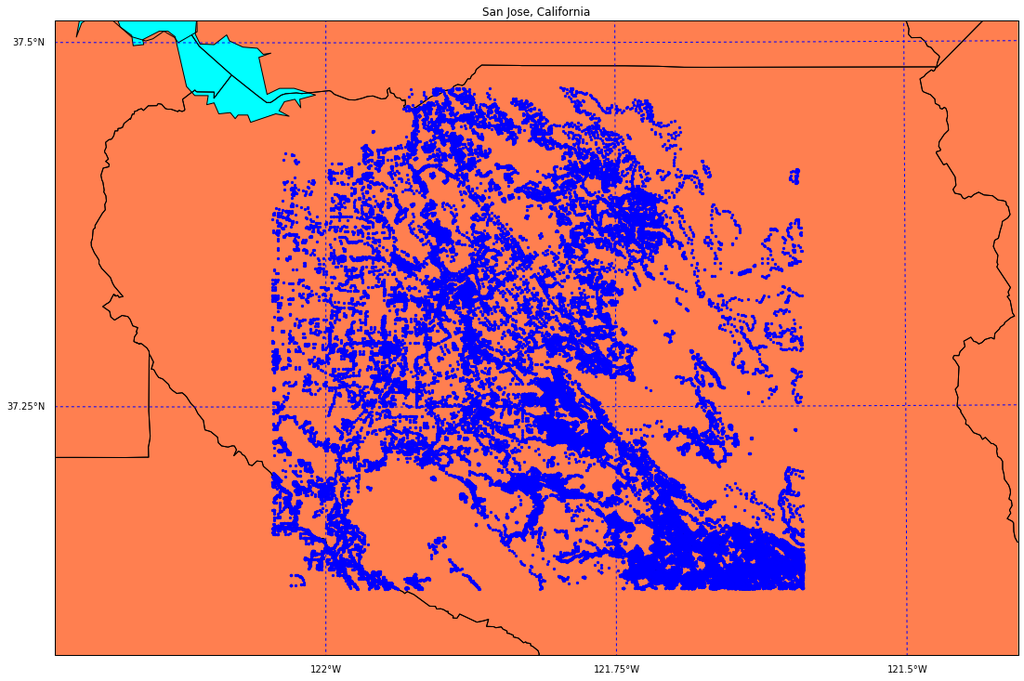

```python
from IPython.display import Image
Image(filename='map_user_nmixter.png')
```

The records added by the second top user "mk408" are shown in the following map as dots

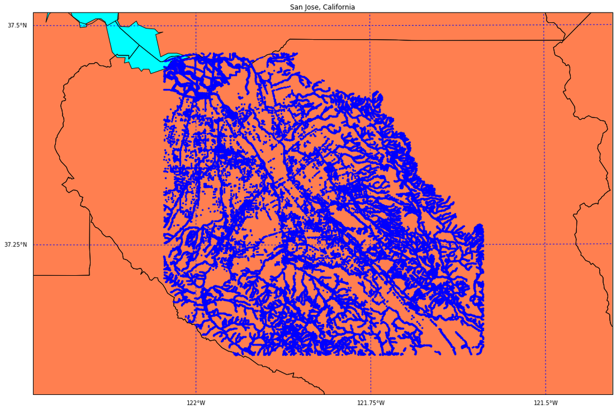

```python
from IPython.display import Image
Image(filename='map_user_mk408.png')
```

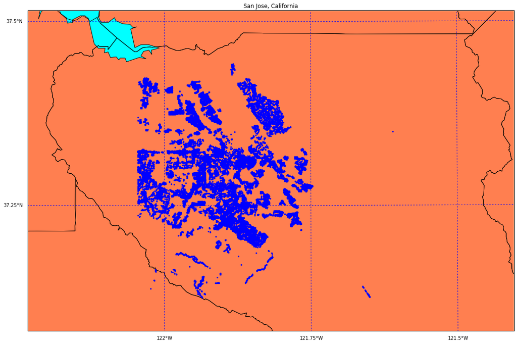

```python
from IPython.display import Image
Image(filename='map_user_Bike_Mapper.png')
```

## 5.3, More data exploration

## 5.3.1, Study "amenity"

We lists the top 40 "amenity", by running the python code "amenity.py". Below is the main code.  
db.sj.aggregate([{'\$match':{'amenity':{'\$exists':1}}},{'\$group':{'_id': '\$amenity', 'count' :{'\$sum':1}}},{'\$sort':{'count':-1}},{'\$limit': 40}])

The results are:  
[{u'_id': u'parking', u'count': 1655},  
{u'_id': u'restaurant', u'count': 850},  
{u'_id': u'school', u'count': 550},  
{u'_id': u'fast_food', u'count': 426},  
{u'_id': u'place_of_worship', u'count': 359},  
.....

*Summary* :

- In general, the records of "amenty" for different facilities are in good shape. Users did not pick up any name they want to use. They did follow the rule of naming, if there is one. Some minor fix is needed such as "parking" and "parking_space" should both be named as "parking".
- There are about 1700 parking lots.
- For dining business, there are restaurant, fast food, cafe, bar, pub. Totally there are about 1570 dining places.
- For education, there are 550 schools, 17 colleges and 13 universities.
- For medicine, there are 74 dentists, 59 pharmacies, 48 clinics, 27 hospitals, 16 veterinary clinics.

### 5.3.2, Study the cuisine of the dining business

The results are:  
[{u'_id': u'mexican', u'count': 119},  
{u'_id': u'burger', u'count': 95},  
{u'_id': u'sandwich', u'count': 91},  
....

Then I draw a bar plot based on the result above.

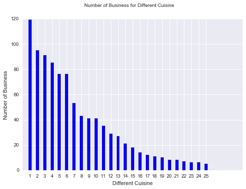

```python
from IPython.display import Image
Image(filename='cuisine.png')
```

Here is how cuisine is numbered:  
1 = mexican, 2 = burger, 3 = sandwich, 4 = vietnamese, 5 = chinese, 6 = pizza, 7 = coffee_shop, 8 = japanese, 9 = indian  
10 = american, 11 = italian, 12 = ice_cream, 13 = thai, 14 = sushi, 15 = chicken, 16 = mediterranean, 17 = regional  
18 = steak_house, 19 = greek, 20 = korean, 21 = asian, 22 = barbecue, 23 = bagel, 24 = seafood, 25 = hawaiian

# 6, Conclusion

- San Jose's map data is quite complete. Top 10 users added 63.9% of the records. I hope more users could jump in and contribute more. Maybe OpenStreetMap should find some ways to encourage more users to do this. Such as publishing the name of Top 10 users, giving out prizes to users who contribute a lot, running a campaign to call people to add data for their neighbourhood.
- To me, the data is quite clean. I notice some discrepancies in the formats of the data. I hope that OpenStreetMap publishes some clear and succinct rules about naming and formatting of data. OpenStreetMap should run some software to filter through the data and fix the errors and bad data. It is diffcult to design the software, though. Using regex is not efficient. Maybe the best way is to apply machine learning algorithms.
- Some other data should be added, such as the static traffic data and speed limit data of the roads. With these data, the user can plan his route from one place to another place. User can add the traffic status at different roads, which shows, on average, at what time which road at which direction will have the traffic jam and how bad is the traffic jam. User can also add the speed limit. This is easy to do. But adding traffic data is difficult. Currently traffic data comes mostly from the traffic data collection companies. It is not free.